# Tarea 8. Control por Realimentación de Estado

Marco Antonio Esquivel Basaldua

```python
import numpy as np
import control as ctr
import scipy as sp
import matplotlib.pyplot as plt
%matplotlib inline
from scipy.integrate import odeint
```

# Control por realimentación del estado

Se considera el sistema cuya función de transferencia es $$ \begin{split} \frac{Y(s)}{U(s)}&=\frac{2}{(s+0.5)(s+0.1)(s-5)}\\ &=\frac{2}{s^3-4.4s^2-2.95s-0.25} \end{split} $$ Y cuya respresentación en variables de estado es $$ \dot{\textbf{x}} = A\textbf{x} + Bu(t)\\ y = C\textbf{x} $$ Donde $$A = \left[\begin{matrix}0 & 1 & 0\\0 & 0 & 1\\0.25 & 2.95 & 4.4 \end{matrix}\right]$$ $$B=\left[\begin{matrix}0\\0\\1 \end{matrix}\right]$$ $$C=\left[\begin{matrix}2 & 0 & 0 \end{matrix}\right]$$

```python
# Funcion de transferencia del sistema
num = np.array([0., 0., 0., 2.])
den = np.array([1., -4.4, -2.95, -0.25])

sys_tf = ctr.TransferFunction(num,den)

# Sistema en variables de estado
A = np.array([[0.,1.,0.],[0.,0.,1.],[0.25,2.95,4.4]])
B = np.array([[0.],[0.],[1.]])
C = np.array([[2.,0.,0.]])
D = np.array([[0.]])

sys_ss = ctr.StateSpace(A, B, C, D)
```

## Simulación del sistema con $u(t)=0$

Simulación en variales de estado considerando $u(t)=0$ y $$ \textbf{x}(0)=\left[\begin{matrix}x_1(0)\\x_2(0)\\x_3(0)\end{matrix}\right] =\left[\begin{matrix}1\\0.5\\-1\end{matrix}\right] $$

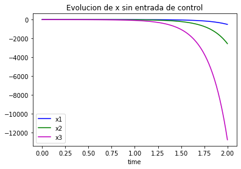

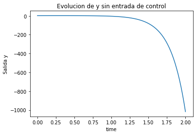

```python
def x_dot(xi,t):
    return A.dot(xi)

x_0 = np.array([1.,0.5,-1.])
t = np.linspace(0,2,101)

x = odeint(x_dot,x_0,t)

y = 2*x[:,0]

plt.plot(t,x[:,0], 'b', label='x1')
plt.plot(t,x[:,1], 'g', label='x2')
plt.plot(t,x[:,2], 'm', label='x3')
plt.title('Evolucion de x sin entrada de control')
plt.legend(loc='best')
plt.xlabel('time')
plt.show()

plt.plot(t,y)
plt.title('Evolucion de y sin entrada de control')
plt.xlabel('time')
plt.ylabel('Salida y')
plt.show()
```

# Estabilidad del sistema

Para que el sistema pueda ser estabilizable mediante la realimentacion por variables de estado, el sistema debe ser controlable y observable. La matriz de controlabilidad del sistema es $$ \mathcal{C}= \left[\begin{matrix} 0 & 0 & 1\\ 0 & 1 & 4.4\\ 1 & 4.4 & 22.31 \end{matrix}\right] $$

La matriz de observabiliad del sistema es $$ \mathcal{O}= \left[\begin{matrix} 2 & 0 & 0\\ 0 & 2 & 0\\ 0 & 0 & 2 \end{matrix}\right] $$

Ya que el determinante de ambas matrices es diferente de cero, se dice que el sistema es controlable y observable y por tanto se puede estabilizar.

```python
C_ = ctr.ctrb(A,B)
print('Matriz de controlabilidad')
print(C_)

O_ = ctr.obsv(A,C)
print('Matriz de Observabilidad')
print(O_)
```

```
Matriz de controlabilidad
[[ 0.    0.    1.  ]
 [ 0.    1.    4.4 ]
 [ 1.    4.4  22.31]]
Matriz de Observabilidad
[[2. 0. 0.]
 [0. 2. 0.]
 [0. 0. 2.]]
```

# Diseno de un controlador por realimentación de estados

Para un sistema con un factor de amortiguamiento del 0.5 y tiempo de asentamiento de 2 segundos se tienen lo sigueintes parametros $$\zeta=0.5$$ $$\omega_n=4$$

El tercer polo $s_3$ se agrega de forma a tener un tercer polo de decaimiento rapido con respecto a los polos $s_1$ y $s_2$.

Haciendo uso de la función control.acker y de los polos antes mencionados se calcula el vector de ganancias $\textbf{K}$.

```python
K = ctr.acker(A,B,[complex(-2,3.4641),complex(-2,-3.4641),-10.])
print(K)
```

```
[[160.2498881   58.94998881  18.4       ]]
```

# Simulacion del sistema con realimentación

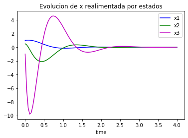

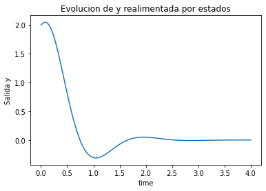

```python
A_BK = A - B.dot(K)
def x_dot_re(xi,t):
    xdot = A_BK.dot(xi)
    xdot = np.array([xdot[0,0], xdot[0,1], xdot[0,2]])
    return xdot

x_0 = np.array([1.,0.5,-1.])
t = np.linspace(0,4,101)
x = odeint(x_dot_re,x_0,t)

y = 2*x[:,0]

plt.plot(t,x[:,0], 'b', label='x1')
plt.plot(t,x[:,1], 'g', label='x2')
plt.plot(t,x[:,2], 'm', label='x3')
plt.title('Evolucion de x realimentada por estados')
plt.legend(loc='best')
plt.xlabel('time')
plt.show()

plt.plot(t,y)
plt.title('Evolucion de y realimentada por estados')
plt.xlabel('time')
plt.ylabel('Salida y')
plt.show()
```

# Entrada escalón unitario

Se desea aplicar una entrada escalón unitario al sistema, a partir del reposo, cuyo diagrama de bloques es

[figure not shown]

## Función de transferencia del sistema realimentado

$$ \begin{split} \frac{Y(s)}{R(s)}&=C(sI-(A-B\textbf{K}))^{-1}B\\ &=\frac{2}{s^3+14s^2+56s+160} \end{split} $$

```python
A_BK = A - B.dot(K)

sys_re = ctr.ss2tf(A_BK, B, C, D)
print(sys_re)
sys_re = ctr.StateSpace(A_BK, B, C, D)
```

```
-5.329e-15 s^2 - 5.684e-14 s + 2
--------------------------------
    s^3 + 14 s^2 + 56 s + 160
```

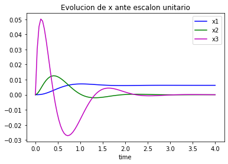

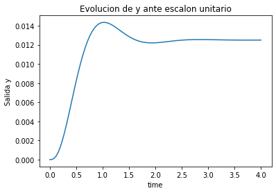

```python
A_BK = A - B.dot(K)
b = np.array([B[0,0],B[1,0] ,B[2,0]])
def x_dot_re(xi, t):
    r = 1.
    xdot = A_BK.dot(xi) + b*r
    xdot = np.array([xdot[0,0], xdot[0,1], xdot[0,2]])
    return xdot

x_0 = np.array([0.,0.,0.])
t = np.linspace(0,4,101)
x = odeint(x_dot_re,x_0,t)

y = 2*x[:,0]

plt.plot(t,x[:,0], 'b', label='x1')
plt.plot(t,x[:,1], 'g', label='x2')
plt.plot(t,x[:,2], 'm', label='x3')
plt.title('Evolucion de x ante escalon unitario')
plt.legend(loc='best')
plt.xlabel('time')
plt.show()

plt.plot(t,y)
plt.title('Evolucion de y ante escalon unitario')
plt.xlabel('time')
plt.ylabel('Salida y')
plt.show()
```

Error en estado estacionario $$e_{ss}=1-y_{ss}=0.9875$$

## Eliminacion del error en estado estacionario

Se introduce una ganancia de precompensacion

[figure not shown]

$$ \overline{N} = -\frac{1}{C[A-B\textbf{K}]^{-1}B} $$

```
79.99994405000001
```

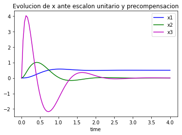

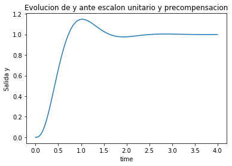

```
Maximo sibreimpulso
0.14743765887002214
```

```python
N = -1./(C.dot(np.linalg.inv(A_BK)).dot(B))
print(N[0,0])
N = N[0,0]

def x_dot_re(xi, t):
    r = 1.
    xdot = A_BK.dot(xi) + b*r*N
    xdot = np.array([xdot[0,0], xdot[0,1], xdot[0,2]])
    return xdot

x_0 = np.array([0.,0.,0.])
t = np.linspace(0,4,101)
x = odeint(x_dot_re,x_0,t)

y = 2*x[:,0]

plt.plot(t,x[:,0], 'b', label='x1')
plt.plot(t,x[:,1], 'g', label='x2')
plt.plot(t,x[:,2], 'm', label='x3')
plt.title('Evolucion de x ante escalon unitario y precompensacion')
plt.legend(loc='best')
plt.xlabel('time')
plt.show()

plt.plot(t,y)
plt.title('Evolucion de y ante escalon unitario y precompensacion')
plt.xlabel('time')
plt.ylabel('Salida y')
plt.show()

print('Maximo sibreimpulso')
print(abs(1-max(y)))
```

## El problema de regulación

Los sistemas de control anteriormente presentados no implementan una realimentación de la salida y. Para ellos se implementa un sistema por regulación. Ya que se esta trabajando con un sistema de tipo cero, el diagrama de bloques a utilizar es el siguiente.

[figure not shown]

Cuya funcion de transferencia es $$ \frac{Y(s)}{R(s)}= \frac{K_IC(sI-A)^{-1}B}{s(1+\textbf{K}(sI-A)^{-1}B) + K_IC(sI-A)^{-1}B} $$

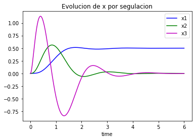

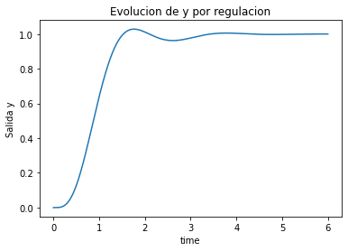

```
Maximo sibreimpulso
0.028632190506580057
```

```python
def x_euler(x0, r, t):
    x = np.zeros((3, len(t)))
    y = np.zeros(len(t))

    h = t[1] - t[0]

    xn = x0
    yn = 2*xn[0]
    x[0,0] = xn[0]
    x[1,0] = xn[1]
    x[2,0] = xn[2]
    y[0] = yn

    chi_n = 0.

    KI = 90.
    for n in range(1, len(t)):
        u = chi_n*KI - K.dot(xn)

        xn1 = xn + h*(A.dot(xn) + B*u)
        x[0,n] = xn1[0]
        x[1,n] = xn1[1]
        x[2,n] = xn1[2]
        #print(xn1)

        yn = 2*xn1[0]
        y[n] = yn

        chi_n = chi_n + h*(r - yn)

        xn = xn1

    return x, y

x_0 = np.array([[0.],[0.],[0.]])
t = np.linspace(0,6,1001)

x,y = x_euler(x_0, 1, t)

plt.plot(t,x[0,:], 'b', label='x1')
plt.plot(t,x[1,:], 'g', label='x2')
plt.plot(t,x[2,:], 'm', label='x3')
plt.title('Evolucion de x por segulacion')
plt.legend(loc='best')
plt.xlabel('time')
plt.show()

plt.plot(t,y)
plt.title('Evolucion de y por regulacion')
plt.xlabel('time')
plt.ylabel('Salida y')
plt.show()

print('Maximo sibreimpulso')
print(abs(1-max(y)))
```